# Final Report

Tweets6 - Naramol Pipoppinyo, Risa Yamazaki, Thanh Dat Nguyen, Eran Kan Kohen and Abdukarim Omar

2023-06-07

# 1 **Introduction**

With the rise of social media, many organizations have used these online platforms to establish a new communication channel with potential customers. Thanks to the bidirectional nature of these platforms, users of sites such as Twitter, Facebook, and Instagram are not not just passive consumers of content but can also actively express their thoughts and opinions on content that these organizations create. Some companies attempt to make use of this unique feature of social media by pursuing novel approaches to marketing in hopes of gaining a competitive advantage. One of these approaches to online marketing communication is brand anthropomorphism, where companies engage in human-like company-consumer communication and relationship building that goes beyond the traditional brand image. Since the emergence of the strategy, there are an increasing number of corporations across various industries that make the shift from traditional “objectified brands” that construct an autonomous brand image to brands with more anthropomorphic features to improve brand perception and build new connections with consumers. The study by Delgado-Ballester et al. (2019), investigated consumer’s general sentiment for apparel brands in experimental form demonstrated that humanized clothing brands were more effective than objectified brands in fostering the positive brand perceptions and emotional connections with consumers, even though that the effectiveness is dependent on the question of whether consumers would prefer to see the specific brand acting like a human. Such effect of anthropomorphism of brands is also visible on the social media in the form of direct consumer engagement with the brand’s official accounts. A supervised machine learning study revealed that consumers engage more with humanized content posted by companies and dialogic replies (Wu et al., 2023). However, the study used the count of Twitter activities (e.g. replies counts, retweets) as the metrics of engagement of consumers, while the online sentiments of consumers towards those anthropomorphized accounts remain unclear, which calls for deeper research of the contents of consumers responses.

This study will expand upon the study conducted by Delgado-Ballester et al. (2019) by focusing on specifically the aviation industry. The aviation industry is a very particular industry since the main service they provide is one that people keep on purchasing even though 40% of the population is scared of flying (Schaaff, 2019). Therefore, they focus maintaining positive customer experience inside and outside of the aircraft. As an industry that provides customers services, customer engagement that leads to the growth in brand equity is significant (Foxall, 2019). Companies from this industry, therefore, constantly seek effective social marketing strategies and implement them to enhance brand visibility and reputations (Foxal, 2019). Since Delgado-Ballester et al. (2019) did not focus on any company from the aviation industry in their study regarding anthropomorphic social media presences, this study will aim to fill in that gap.The explored results delivered in this study is expected to add insights on the strategic brand positionings for aviation companies.

As a service industry, aviation companies must be successful with maintaining positive sentiments among customers by leveraging communication strategies, while not depriving trusts among consumers about the quality of service. This study will aim to see if either the sentiment or the quantity of interactions differ among the selected Twitter accounts.

Therefore, we chose the companies to compare the consumer’s online response and sentiments with a research question, “What is the effect of brand anthromorphism on social media engagement for aviation industry?” This research question would help the aviation industry to understand online consumer behavior and utilize it for their strategic positioning.

The research question will be answered by addressing sub research questions as follows;

- How does brand anthropomorphism affect the number of likes, re-tweets, replies on Twitter?
- How does brand anthropomorphism affect the sentiments of consumers on Twitter?
- Does brand anthropomorphism have an interaction effect on the sentiment and interaction metrics on Twitter?

This study serves mostly as an exploratory study into the effects of brand anthropomorphism on the engagement metrics of the aviation industry, and does not attempt to assert causal relationships between these variables.

# 2 **Data Collection and Processing**

### 2.0.1 Data Collection

In total, six different airlines were used for data collection including RyanAir, EasyJet, Emirates, Qatar, Turkish Airline, and United airlines. We used the ‘users’ end point to collect tweets from specific Twitter accounts by specifying the userID with this line of code (see table 1).

**Table 1**

*Overview airlines and their Twitter User ID*

| Airline | UserID |
| --- | --- |
| RyanAir | 1542862735 |
| EasyJet | 38676903 |
| Emirates | 821045162 |
| Qatar | 14589119 |
| Turkish Airlines | 18909186 |
| United | 260907612 |

Our full parameters were as follows:

```r
params <- list(max_results = 50,
               tweet.fields = ALL_tweet_fields,
               expansions = ALL_expansions,
               exclude = "replies")
```

Due to the API limitation of 10,000 tweets, we wanted to collect as much data and information as possible per request and thus, took a more exhaustive approach to data collection. Meaning that even when we did not think we wanted to use certain information, we made sure to specify all “tweet fields” and all “expansions” from the based on the file ‘aux_objects.R’:

```r
ALL_tweet_fields <- c("attachments",
                      "author_id",
                      "context_annotations",
                      "conversation_id",
                      "created_at",
                      "entities",
                      "geo",
                      "id",
                      "in_reply_to_user_id",
                      "lang",
                      "possibly_sensitive",
                      "public_metrics",
                      "referenced_tweets",
                      "reply_settings",
                      "source",
                      "text",
                      "withheld")
```

```r
ALL_expansions <- c("attachments.poll_ids",
                    "attachments.media_keys",
                    "author_id",
                    "entities.mentions.username",
                    "geo.place_id",
                    "in_reply_to_user_id",
                    "referenced_tweets.id",
                    "referenced_tweets.id.author_id")
```

We first did many rounds of data sampling in which left us with approximately 6000 tweets for the official data collection. In total, between 499 - 500 tweets were specified per airline, leading to our “base” data to include 2996 tweets. These tweets will be referred to as “responses” for the rest of the research. We excluded replies in our parameters because during our testing, we found that most of the “reply” type of Tweets lacked any public metrics such as retweets, likes, shares and comments. The anthropomorphic brands also had an added advantage in regards to the engagement of their replies since many of the traditional airlines used their replies for customer support (which naturally receive little engagement), keeping the replies in could have therefore skewed results. We decided to set our max results to 50 meaning that to get to 500 tweets, we requested the API 10 times via a loop to reach 500.

This code was replicated six times for all airlines using the httr package:

```r
while(request_number < N_requests) {
    tic("duration for request number: ")
    response <- httr::GET(url = url_handle,
                          config = httr::add_headers(.headers = my_header[["headers"]]),
                          query = params)

    httr::status_code(response)
    obj <- httr::content(response)

    obj[["meta"]][["next_token"]]

    cat(paste0("Response Request number: ", request_number,
               " has HTTP status: ", httr::status_code(response), "\n"))

    response_objects[[request_number]] <- response
    names(response_objects)[request_number] <- paste0("request_", request_number)
    request_number <- request_number + 1


    params[["pagination_token"]] <- obj[["meta"]][["next_token"]]


    timeline_response <- httr::content(response)
    tweets <- timeline_response$data
    Sys.sleep('60')

    for (tweet in tweets) {
      tweet_id <- tweet$id

      params_reply <- list(query = paste0("conversation_id:", tweet_id),
                           tweet.fields = ALL_tweet_fields,
                           expansions = ALL_expansions,
                           max_results = 20)


      response_reply <- httr::GET(url = url_conversation,
                                  config = httr::add_headers(.headers = my_header[["headers"]]),
                                  query = params_reply)

      httr::status_code(response_reply)

      replies_response <- httr::content(response_reply)

      replies_response[["meta"]][["next_token"]]

      cat(paste0("Reply Request number: ", request_number_replies,
                 " has HTTP status: ", httr::status_code(response_reply), "\n"))

      replies_objects[[request_number_replies]] <- response_reply
      names(replies_objects)[request_number_replies] <- paste0("request_", request_number_replies)

      request_number_replies <- request_number_replies + 1

      Sys.sleep('60')


    }


    toc()
  }
```

As you can see in the code, within the loop, we do a second data request specifically using the recent search endpoint to collect specific replies from the tweets we collected in our outer loop:

```r
url_conversation <- paste0("https://api.twitter.com/2/tweets/search/recent")
```

We did this by specifying the “conversation ID” in the query based on the “tweet_id” collected from the outer loop.

```r
      params_reply <- list(query = paste0("conversation_id:", tweet_id),
                           tweet.fields = ALL_tweet_fields,
                           expansions = ALL_expansions,
                           max_results = 20)
```

We collected a maximum of 20 replies per tweet and so in theory we could get a max of 1000 replies based on the 50 tweets. Since we collect a total of 500 tweets per airline, this could lead to a theoretical maximum of 10,500 datapoints per airline. However, knowing that most tweets do not have many replies, we would not meet this criteria which would be above the 10000 cap of the API.

### 2.0.2 Raw Data Processing

When working with the Twitter API using httr package, the response output is a JSON file. Therefore we had to process the data into a usable dataframe on R. The JSON response contains several key components: “meta”, “includes”, and “data”. “Meta” was used in the loops to retrieve the “next_token” value for pagination. The “data” file includes the main data from the end point that was used for the API request. The “includes” contains additional data that may be related to the main data collection. Both the “data” and “includes” were extracted and processed into into separate lists called ‘raw_tweets’ and another one for the includes called ‘raw_includes’ in ‘Aviation_process_data.R’. These were processed into ‘df_tweets’ and ‘df_ref_tweets’ respectively with these values specified:

```r
df_tweets <- raw_tweets %>%
  {tibble(tweet_id           = map_chr(., "id"),
          text               = map_chr(., "text"),
          lang               = map_chr(., "lang"),
          created_at         = map_chr(., "created_at"),
          author_id          = map_chr(., "author_id"),
          conversation_id    = map_chr(., "conversation_id"),
          reply_settings     = map_chr(., "reply_settings"),
          geo_place_id       = map_chr(., f_get_geo_placeid),
          retweet_count      = map_int(., f_get_retweet_count),
          reply_count        = map_int(., f_get_reply_count),
          like_count         = map_int(., f_get_like_count),
          quote_count        = map_int(., f_get_quote_count),
          tweet_type         = map_chr(., f_get_tweet_type),
          ref_tweet_id       = map_chr(., f_get_ref_tweet_id))}
```

```r
df_ref_tweets <- raw_ref_tweets %>%
  {tibble(ref_tweet_id           = map_chr(., "id"),
          ref_text               = map_chr(., "text"),
          ref_lang               = map_chr(., "lang"),
          ref_created_at         = map_chr(., "created_at"),
          ref_author_id          = map_chr(., "author_id"),
          ref_conversation_id    = map_chr(., "conversation_id"),
          ref_reply_settings     = map_chr(., "reply_settings"),
          ref_geo_place_id       = map_chr(., f_get_geo_placeid),
          ref_retweet_count      = map_int(., f_get_retweet_count),
          ref_reply_count        = map_int(., f_get_reply_count),
          ref_like_count         = map_int(., f_get_like_count),
          ref_quote_count        = map_int(., f_get_quote_count),
          ref_tweet_type         = map_chr(., f_get_tweet_type),
          ref_ref_tweet_id       = map_chr(., f_get_ref_tweet_id))}
nrow(df_ref_tweets)
df_ref_tweets <- distinct(df_ref_tweets)
nrow(df_ref_tweets)
```

These two data sets are created for the “responses” and “replies” for each airline, meaning that each airline has four datasets. Using EasyJet as an example:

1. ‘df_ref_tweets_EJ’ includes the reference tweets of the EasyJet ‘responses’,
2. ‘df_tweets_EJ’ includes the tweets of the EasyJet ‘responses’,
3. ‘replies_df_ref_tweets_EJ’ includes the reference tweets of the EasyJet ‘replies’,
4. ‘replies_df_tweets_EJ’ includes the reference tweets of the EasyJet ‘replies’,

Due to our exhaustive data collection approach, we received reference tweets from the expansions. However since we did not use it in our analysis, we will not go into more detail on this data for the rest of the research.

These dataframes are created for all the airlines including EasyJet, including RyanAir, Emirates, Qatar, Turkish Airlines, and United Airlines. In the end, we received a total of 2996 responses and 1204 replies for all 6 airlines (see table 2). The small sample size is due to the fact that replies only go 7 days back from the day of data collection. To deal with the request time limit, we spaced the requests for every minute.

**Table 2**

*Number of Responses and Replies Collected per Airline*

| Airline | Responses | Replies |
| --- | --- | --- |
| RyanAir | 499 | 200 |
| EasyJet | 500 | 135 |
| Emirates | 500 | 161 |
| Qatar | 499 | 348 |
| Turkish Airlines | 499 | 217 |
| United | 499 | 143 |

Initially, the aforementioned collected data was loaded into an empty R file. Each company had their own dataframe and in order to make the future analyses possible and easy, several new variables were added into the dataframes. The variable “ant_dummy” is a binary variable which indicates whether the company uses anthropomorphic Tweets. Ryanair and United Airlines received a score of 1, whereas the other companies received a 0. The “company” variable had the name of the company to make the analyses easier, and a column called “follower_count” was created to scale some results in the latter parts of the study. Each company received their follower counts as of 25th of May 2023. Once the modifications were done, the dataframes were merged into a complete dataframe.

The processing continued with the creation of a new dataframe which only consisted of main Tweets, removing the replies - even though we excluded them in the previous steps, a small fraction of replies still managed to slip through. Later, new columns were created with the scaled version of each interaction metric. This was created by dividing the metric by the follower count. The analyses utilize both the scaled and non-scaled versions.

Finally, the processing regarding the sentiment scores of the Tweets started with the removal of URL’s and non-alphanumeric elements from the chosen Tweets. The sentiment scores were generated using the processed texts. The same process was done for the replies. However since replies are more complicated, additional filters were applied which ensured the texts were written in English and were not empty cells after the removal of non-alphanumeric elements. With the sentiment scores generated, the dataframes were ready for the analyses.

# 3 **Data Analysis**

### 3.0.1 Methodology

Finally, the study investigates the relationship between the sentiment scores and interaction metrics. This examination was deepened by adding anthropomorphism as an interaction variable. Linear regression tests and line graphs enabled close inspection of the relationship between all selected variables. The linear regression analyses were chosen due to its ability to illustrate the effect of moderation within subgroups (Wermuth, 1989). Moreover, it has been proven that visualization of interaction effects using linear regression has been proven to make the results of analyses much easier to interpret (Hayes & Montoya, 2017).

### 3.0.2 Results

Below, the results of the statistical tests, as well as the visualizations will be presented. The analyses and the generation of the visualizations can be found [here](https://github.com/Digital-Footprints/ADF2023GP-tweets-6/blob/main/data_analysis/analysis.R).

```r
results_csv <- read.csv(here("data_analysis","results.csv"))
#Round numbers
results_csv[, 2:4] <- round(results_csv[, 2:4], digits = 5)
#p-values for readability
results_csv$p_value <- ifelse(results_csv$p_value == 0.000000, "<0.000001", results_csv$p_value)
#change name of columns
colnames(results_csv)[1] <- "Metrics"
colnames(results_csv)[2] <- "Group 0"
colnames(results_csv)[3] <- "Group 1"
colnames(results_csv)[4] <- "P-Value"
#change variable names for readability
results_csv$Metrics <- str_to_title(gsub("_", " ", results_csv$Metrics))
```

Initially, the results of the t-tests are imported. Afterwards, several steps were taken to make sure the results were easy to understand and readable. Initially, all of the numbers were rounded to take less space. Afterwards, the extremely low p-values were changed to illustrate that the probability of a statistical difference being by chance is less than one in a million. Finally, the names of the columns and the variables were changed for better presentation (see table 3).

**Table 3**

*Overview descriptive data*

```
##
##
## |Metrics               |   Group 0|    Group 1|P-Value   |
## |:---------------------|---------:|----------:|:---------|
## |Retweet Count         |  44.64914|  227.73349|<0.000001 |
## |Reply Count           |  21.23176|   88.07879|0.00135   |
## |Like Count            | 357.74785| 3340.47972|<0.000001 |
## |Quote Count           |   4.31277|   34.26767|<0.000001 |
## |Retweet Count Scaled  |   0.00003|    0.00029|<0.000001 |
## |Reply Count Scaled    |   0.00002|    0.00010|4e-05     |
## |Like Count Scaled     |   0.00022|    0.00444|<0.000001 |
## |Quote Count Scaled    |   0.00000|    0.00004|<0.000001 |
## |Reply Sentiment Score |   0.04188|   -0.02666|0.06444   |
```

In table 3, Group 0 refers to the non-anthropomorphic group whereas Group 1 refers to the anthropomorphic one. The table aims to show the average score each group received for the chosen metric and see if the t-test significant was statistically significant. As seen above, the anthropomorphic group performs better in all interaction metrics in a statistically significant degree. This is true for the true values as well as the scaled values, indicating that the follower counts do not play a role in this performance. However, the relationship between anthropomorphism and sentiment scores of the replies do not seem to be statically significant (p>0.05). This indicates that, even though the means are different, the null hypothesis concerning the reply sentiments and anthropomorphism cannot be rejected. On the other hand, it is clear that anthropomorphism boosts interaction.

These relationships are further elaborated on with the following visualizations:

**Figure 1**

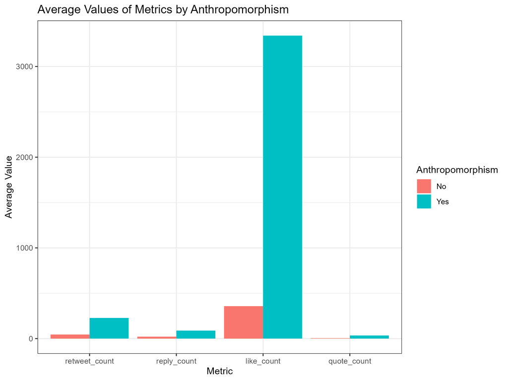

Figure 3.1: Metrics Barchart

The plot above shows the non-scaled metrics (see figure 1).

**Figure 2**

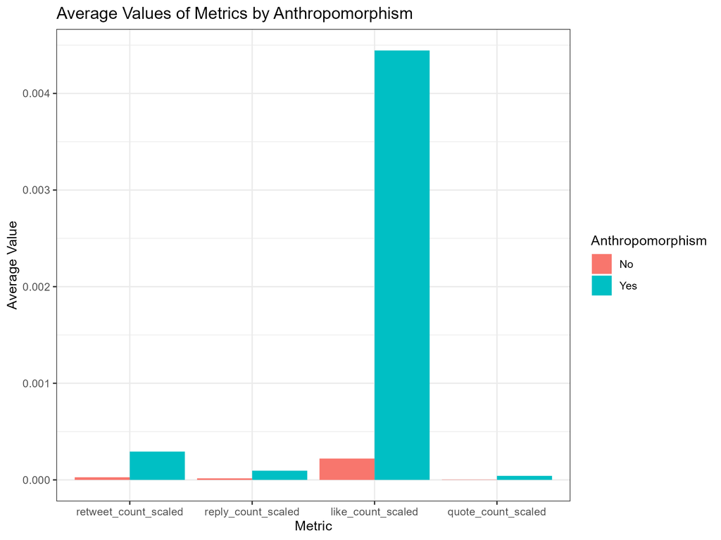

Figure 3.2: Metrics Barchart Scaled

Figure 2 shows the scaled metrics. The similarity of both of the plots highlights the lack of difference follower counts make.

Afterwards, the linear regression results were loaded.

The results of all of the regressions are presented below, in the same order as the table above (see table 3).

**Table 4**

*Overview results of the regression across various Twitter metrics*

```
##
## ===================================================================================
##                                                 Dependent variable:
##                                 ---------------------------------------------------
##                                 retweet_count reply_count  like_count   quote_count
##                                      (1)          (2)          (3)          (4)
## -----------------------------------------------------------------------------------
## sentiment_score                    -13.147      -4.965       67.761       -2.824
##                                   (58.424)     (30.522)     (728.320)     (9.246)
##
## ant_dummy                        222.672***    54.136***  3,909.329***   29.781***
##                                   (34.812)     (18.186)     (433.969)     (5.509)
##
## sentiment_score:ant_dummy        -288.285***    82.328    -6,329.181***   -1.944
##                                   (103.661)    (54.154)    (1,292.245)   (16.405)
##
## Constant                          48.671**      22.751*      337.018       5.177
##                                   (23.523)     (12.289)     (293.235)     (3.723)
##
## -----------------------------------------------------------------------------------
## Observations                        2,727        2,727        2,727        2,727
## R2                                  0.021        0.009        0.039        0.018
## Adjusted R2                         0.020        0.008        0.038        0.016
## Residual Std. Error (df = 2723)    660.225      344.911     8,230.409     104.484
## F Statistic (df = 3; 2723)        19.268***    8.392***     37.297***    16.234***
## ===================================================================================
## Note:                                                   *p<0.1; **p<0.05; ***p<0.01
```

As seen above from table 4, similar to the t-test scores, the interaction metrics are higher for anthropomorphic accounts. Moreover, for likes and tweets, there is a statistically significant interaction effect between anthropomorphism and sentiment score. The combination of higher sentiment and anthropomorphism leads to lower likes and tweets, and vice versa.

**Table 5**

*Overview scaled results of the regression across various Twitter metrics*

```
##
## ============================================================================================================
##                                                             Dependent variable:
##                                 ----------------------------------------------------------------------------
##                                 retweet_count_scaled reply_count_scaled like_count_scaled quote_count_scaled
##                                         (1)                 (2)                (3)               (4)
## ------------------------------------------------------------------------------------------------------------
## sentiment_score                       -0.00001            -0.00001          -0.00003           -0.00000
##                                       (0.0001)           (0.00003)           (0.001)          (0.00001)
##
## ant_dummy                            0.0003***           0.0001***          0.005***          0.00004***
##                                      (0.00005)           (0.00002)           (0.001)          (0.00001)
##
## sentiment_score:ant_dummy            -0.0004***            0.0001           -0.009***          -0.00001
##                                       (0.0001)           (0.00005)           (0.002)          (0.00002)
##
## Constant                              0.00003             0.00002*           0.0002            0.00000
##                                      (0.00003)           (0.00001)          (0.0004)          (0.00000)
##
## ------------------------------------------------------------------------------------------------------------
## Observations                           2,727               2,727              2,727             2,727
## R2                                     0.025               0.014              0.042             0.018
## Adjusted R2                            0.024               0.013              0.041             0.017
## Residual Std. Error (df = 2723)        0.001               0.0003             0.011             0.0001
## F Statistic (df = 3; 2723)           22.911***           13.290***          39.813***         16.315***
## ============================================================================================================
## Note:                                                                            *p<0.1; **p<0.05; ***p<0.01
```

Since there are 8 different analyses, there are 8 unique linear regression graphs. Since highlighting all would be quite repetitive, only the Retweet count non-scaled and like count scaled graphs will be shown. All of the visualizations can be found [here](https://github.com/Digital-Footprints/ADF2023GP-tweets-6/tree/main/data_analysis/visualizations).

**Figure 3**

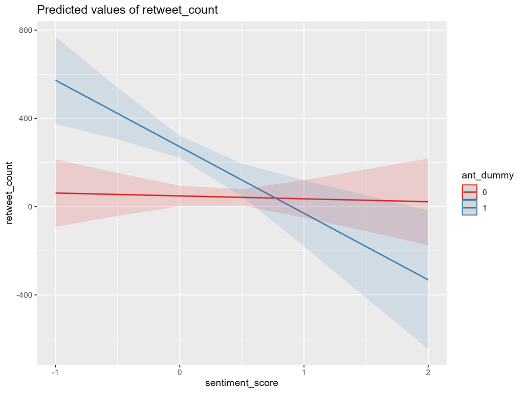

Figure 3.3: Retweets Linear Regression

Figure 3 shows the relationship between anthropomorphism, sentiment of replies, and retweets. As can be clearly seen, there is quite a staggering interaction effect which shows that the relatively straight curve for non-anthropomorphic gains a negative slope for anthropomorphic accounts where a negative sentiment correlates with more retweets. It is important to state that the graph indicates that for high sentiment scores the Retweet count would be negative. This is due to the linear regression model following a straight correlation.

**Figure 4**

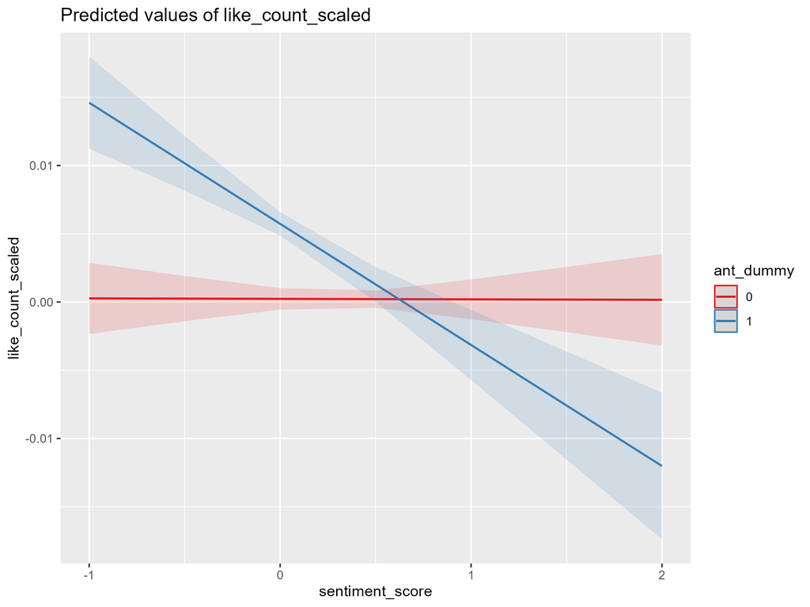

Figure 3.4: Likes Scales Linear Regression

The same interpretation for retweets can be made for the scaled like values. Again, a tweet with higher likes for an anthropomorphic correlates with replies with more negative sentiments (see figure 4).

# 4 **Conclusions and Implications**

This study revealed that the chosen anthropomorphized Airline Twitter accounts are associated with more engagements measured in retweets, replies, likes and quotes by Twitter users. The effect was the most prominent for the number of likes. Mochon (2017), studied the social media platform Facebook and concluded that the number of likes were associated with the positive offline attitudes of consumers towards the companies, especially prominent when the company account has an objective of promotional communications with consumers. As a social media platform with similar features, the larger number of likes for anthropomorphic companies’ tweets possibly reflect its association to positive offline perceptions among consumers.

The count of retweets is another Twitter engagement metrics that was an indicator of interaction levels for aviation companies. According to a research by [Parilla-Ferrer et al (2015), tweets that are deemed to be informative got more retweeted by users. Another study by Abdullah et al.(2015) added that the tweets typically retweeted by users are typically perceived by the users to be important and interesting. Additionally, the actions of retweets could be attributed to the tweet users. Provided those supporting studies, the result can be explained that the human-like tweets and Twitter accounts of the companies in aviation industries are more likely to be perceived by consumers as more interesting and important, and it is able to motivate consumers to share the contents among their communities.

However, this study used the anthropomorphic companies which are associated with lower quality products and services. Therefore, as Delgado-Ballester (2019) concluded in their research, it is plausible to conclude here that the effect of the human-like Tweet behaviors are preferred by consumers, at least for the cases of companies that has the initially aligned brand image to such behaviours. To sum up, anthropomorphism is an effective differentiation strategy for aviation companies to stimulate Twitter users to respond to the companies’ tweets and to activate two-ways interactions with consumers by emphasizing the company’s brand images.

This study extended the literature of previous studies by investigating the effects of anthropomorphic style of tweeting on the consumer sentiments towards the aviation firms. This was achieved by assessing the sentiment scores of replies by Twitter users to the Aviation companies’ tweets. Unfortunately, the effects observed between the two factors were not statistically significant. Therefore it was not possible in this study to determine whether anthropomorphic tweets by companies would be beneficial or detrimental for consumers’ actual brand perceptions and attitudes towards the brands.

However, the negative interactions between the sentiment scores of the consumers’ replies and the counts of likes and retweets were statistically significant for anthropomorphic aviation companies Twitter accounts, regardless of the number of followers of the account. The results provides a surprising, but contextually expected insight. Primarily by Ryanair, anthropomorphic Twitter accounts behave beyond a formal corporate-like attitudes by using sarcastic and dark jokes as content. The replies to those tweets are also absurd, dark and sarcastic towards the companies’ services but as jokes. Therefore, the negative associations actually connotes the positive friend-like relationship building between the anthropomorphic aviation companies and Twitter users. This suggests that the aviation companies which intends to build close communications and communities with their potential consumers could benefit from the anthropomorphic style of tweets.

To conclude, this study discovered, through statistical analyses, that anthropomorphic tweets could be an effective social media tool for aviation companies when trying to build an easily accessible impression. This correlates with higher social media presence and greater interaction. The insights provided serve as a stepping stone for future researches to further investigate the effects of anthropomorphic behavior on the companies’ actual reputations on their services and on the consumers’ purchase intentions.

# 5 **Limitations and Future Improvements**

The study suffered from several limitations due to the Twitter API. Therefore, if future studies want to develop upon the discussed implications, there are some factors to consider. The first factor regards to the limitations of obtaining tweets. Twitter maintains a quota system for requesting Tweets through their API. Apart from their free plan, the cheapest plan one is allowed to request 10.000 tweets, if one exceeds the limitations, they must purchase an additional plan to continue collecting data. This caused the scope of this study to be limited to only having six brands observed, from which two brands were anthropomorphic. This could result in that results are skewed. Although this study aimed to explore the concept of anthropomorphism within consumer engagement, we recommend future studies to include more aviation brands and in addition, to create subgroups based on consumer segments. For example, Ryanair is a budget airline and as such will attract a different base than Emirates which caters to consumers that prefer a more premium experience. By having more brands, it is possible to see how anthropomorphism is deployed within the various aviation market segments.

The second limitation regards the limited time window Twitter allows to collect certain tweet types. One of the variables used in this study was sentiment, this was created by observing the replies of users under a brand’s tweet. Twitter maintains a 7-day window for how far a user can request to collect replies under a tweet. This limitation caused that the study were only able to request all the replies of tweets under a post that was posted within that 7-day window. Consequently, this creates a small sample size and sample bias making the model more prone to outliers. Outliers can impact how positive or negative comments are on average for a particular tweet, as well as the quantity of comments on a post. If the 7-day limitation did not exist, the issue of outliers would be suppressed as there are more datapoints to observe the trajectory of consumer sentiment. In addition, it provides the opportunity to see if trends are visible regarding in the number of likes, comments, and retweets a brand receives that deploy anthropomorphism versus brands that do not use it.

The last limitation regards the lack of access to demographic data of users that interact with the brands. Literature has shown that different consumer bases interact with a brand differently (Azar et al., 2016). As such, it is interesting to observe which type of consumers (based on demographic data such as age, gender, and country of origin), are more likely to interact with brands that use anthropomorphism in their communication. For this study, it was not decided to observe this sub-question and rather observe the general Twitter population, as this data is not provided by Twitter’s API to third parties as it contains sensitive user information. Data privacy regulations such as GDPR restrict how much data can be processed by third-party actors.

## 5.1 **References**

Abdullah, N. A., Nishioka, D., Tanaka, Y., & Murayama, Y. (2015). User’s action and decision making of retweet messages towards reducing misinformation spread during disaster. *Journal of Information Processing*, *23*(1), 31–40. https://doi.org/10.2197/ipsjjip.23.31

Azar, S., Machado, J. C., Vacas-De-Carvalho, L., & Mendes, A. M. (2016). Motivations to interact with brands on Facebook – Towards a typology of consumer–brand interactions. *Journal of Brand Management, 23*(2), 153–178. https://doi.org/10.1057/bm.2016.3

Delgado-Ballester, E., Palazon, M., & Peláez, J. M. M. (2019). Anthropomorphized vs objectified brands: which brand version is more loved? *European Journal of Management and Business Economics, 29*(2), 150–165. https://doi.org/10.1108/ejmbe-04-2019-0063

Foxall, G. R. (2018). An economic psychology of the marketing firm. In A. Lewis (Ed.), *The Cambridge Handbook of Psychology and Economic Behaviour* (2nd ed., pp. 365–402). Cambridge University Press. https://doi.org/10.1017/9781316676349.013

Hayes, A. F., & Montoya, A. K. (2017). A Tutorial on Testing, Visualizing, and Probing an Interaction Involving a Multicategorical Variable in Linear Regression Analysis. *Communication Methods and Measures, 11*(1), 1–30. https://doi.org/10.1080/19312458.2016.1271116

Kim, T. K. (2015). T test as a parametric statistic. *Korean Journal of Anesthesiology*, *68*(6), 540. https://doi.org/10.4097/kjae.2015.68.6.540

Loh, C. (2023, April 29). *Controversial yet entertaining: Examining ryanair’s social media strategy*. Simple Flying. https://simpleflying.com/ryanair-social-media-strategy/

Mochon, D., Johnson, K., Schwartz, J., & Ariely, D. (2017). What Are Likes Worth? A Facebook Page Field Experiment. *Journal of Marketing Research*, *54*(2), 306–317. https://doi.org/10.1509/jmr.15.0409

Parilla-Ferrer, B.E., Fernandez, P.L., & Ballena, J.T. (2015). Automatic classification of disaster-related tweets. (2014, December 28). https://www.semanticscholar.org/paper/Automatic-Classification-of-Disaster-Related-Tweets-Parilla-Ferrer-Fernandez/f82e985ad5abc2f6f219f9cd83c248ebd132e3e4

Schaaff, S. V. (2019, October 12). Lots of Americans have a fear of flying. There are ways to overcome the anxiety disorder. *Washington Post*. https://www.washingtonpost.com/health/lots-of-americans-have-a-fear-of-flying-there-are-way-to-overcome-the-anxiety-disorder/2019/10/11/d4746d84-d338-11e9-86ac-0f250cc91758_story.html

Schlappig, B. (2022). *Ryanair’s Hilarious, Rude, Savage Twitter Team*. One Mile at a Time. https://onemileatatime.com/insights/ryanair-twitter/

Wermuth, N. (1989). Moderating effects of subgroups in linear models. *Biometrika, 76*(1), 81–92. https://doi.org/10.1093/biomet/76.1.81

Wu, L., Dodoo, N. A., & Choi, C.-W. (2023). Brand anthropomorphism on Twitter: Communication strategies and consumer engagement. *Journal of Product & Brand Management*, *ahead-of-print*(ahead-of-print). https://doi.org/10.1108/JPBM-12-2021-3787